# Final Deliverable Project cmsc320 (1)

**Analyzing the Impact of Video Game Ratings on Global Sales**

Course: CMSC320 Final Project

Name: Nathan Tekle

Contributions: I did this project individually. Here are the following sections I worked on:

A. Project Idea: I decided to explore how critic and user ratings affect the video game global sales

B. Data Curation and Preprocessing: I cleaned the data by removing missing values and making sure only the rows with complete information existed.

C. Data Exploration and Statistics Summary: I conducted the hypothesis testing, regression testing, and correlation analysis to examine the relationships between the variables

D. ML Algorithm Design/Development: I implemented Ridge Regression model using critic scores as predictors of global sales. Also, I used it to reduce overfitting and handle potential multicollinearity

E. ML Algorithm Training and Test Data Analysis: I split the dataset into training and testing sets. First, I trained the model on the training data and then I evaluated its performance on the testing sets using mean squared error and r^2 scores.

F. Visualization, Result Analysis, Conclusions: I created scatter plots with regression lines to visually show the difference between an actual plot and predicted plot. I intepreted them to determined how well the critic scores predict the global sales and give key insights from the results.

G. Final Tutorial Report Creation: I wrote and organized the whole final project notebook. I combined code and explatory text in each section, including the section requiring visualization, to make the report informative.

**Introduction**

The video game industry makes multi-billion dollars per year. They make more money than what the hollywood, gun, and other industries make combined. This makes the developers and publishers to wonder how video game sales drive up the global sales. Therefore, with this project, I aim to answer this question: **How do critic and user review scores impact the global video game sales?** Answering this question can give the better perspective to the marketers and game designers on how video games should be prioritized. If strong ratings lead to higher sales, then the companies who have games with this rating should have the courage to market and sell the game globally to the public.

**Data Curation**

The dataset I used to make predictive analysis on is Video_Games_Sales_as_at_22_Dec_2016.csv. I got this dataset from the source here: https://www.kaggle.com/datasets/dileepsahu/video-games-sale-data-set-dec-2016.

It contains information about distinct video games, including platform, genre, release year, critic scores, user scores, NA sales, EU sales, JP sales, global sales, etc. For the preprocessing part, I cleaned the data by removing rows with missing or null values to ensure complete and accurate dataset. The cleaned data was stored in pandas DataFrame and was used for different parts of analysis in this project.

```python
import pandas as pd
import matplotlib.pyplot as plt
from scipy.stats import ttest_ind
video_game_dataset = pd.read_csv("Video_Games_Sales_as_at_22_Dec_2016.csv")
clean_data = video_game_dataset.dropna()
```

The second section is **Data Exploration and Summary Statistics**. I have selected three kinds of statistical testings down below and will go over the analysis of the findings of each of them.

The first test is to figure out if **games with higher critic scores sell more globally significantly** Ho(null): **The average global sales are the same for games with high and low critic scores** H1(alternative): **Games with higher critic score have different global sale(possibly higher) than games with lower critic score.** The reason to use this test is because a t-test does a great job to compare the means of two groups. In this case, we're testing if the difference in average global sales between high and low critic scores is statistically significant.

```python
high_scores = clean_data[clean_data['Critic_Score']>=75]['Global_Sales']
low_scores = clean_data[clean_data['Critic_Score']<75]['Global_Sales']
#I'm using a two-sample t-test here
t_stat, p_val = ttest_ind(high_scores, low_scores, equal_var=False)
print("t_statistic: ",t_stat, "p_value: ", p_val)
```

```
t_statistic:  15.867379060297099 p_value:  8.785795380944946e-55
```

Since the p-value is 8.7857e-55, which is extremely smaller than 0.05, we reject the null hypothesis on top. We conclude that games with higher critic scores sell significantly higher than games with lower critic scores

**Figure 1: Boxplot of Global Sales by Critic Score**

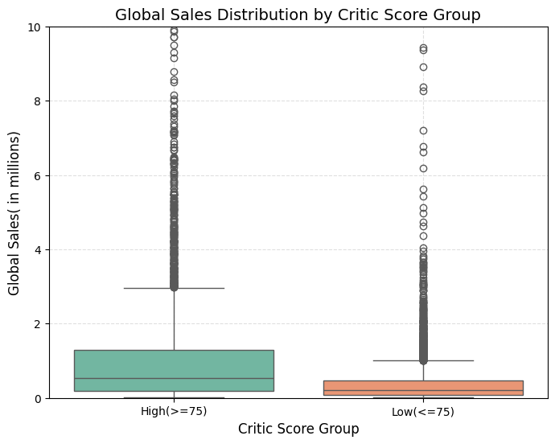

```python
import seaborn as sns
import matplotlib.pyplot as plt
clean_data['Critic_Score'] = pd.to_numeric(clean_data['Critic_Score'])
clean_data['Critic_Score_Group'] = clean_data['Critic_Score'].apply(lambda x: 'High(>=75)' if x >= 75 else 'Low(<=75)')
plt.figure(figsize=(8,6))
sns.boxplot(x='Critic_Score_Group',y='Global_Sales', data=clean_data, palette='Set2', hue=None)
plt.title("Global Sales Distribution by Critic Score Group", fontsize = 14)
plt.xlabel("Critic Score Group", fontsize=12)
plt.ylabel("Global Sales( in millions)", fontsize=12)
plt.grid(True, linestyle='--', alpha=0.4)
plt.ylim(0,10)
plt.show()
```

As you can see above, this boxplot shows that games with higher critic scores(>=75) tend to sell more globally. The middle line is higher and more high-score games have strong sales. The games with lower critic scores(<=75) tend to not sell enough globally. This indicates that games with lower critic scores tend to not performed well in global sales.

The second test is to use the correlation to see if there is **a strong relationship between User_Score and Global_Sales.** The reason to use this test is because the pearson correlation coefficient does a great job measuring how strong two variables are linearly related. This can help us to get an idea whether higher user scores are generally associated with more global sales.

```python
from scipy.stats import pearsonr
clean_data = clean_data[clean_data['User_Score']!="tbd"]
clean_data['User_Score'] = clean_data['User_Score'].astype(float)
correlation, p_vals = pearsonr(clean_data['User_Score'], clean_data['Global_Sales'])
print("Correlation coefficient: ",correlation)
print("P_value is ",p_vals)
```

```
Correlation coefficient:  0.08834852634696723
P_value is  2.636855123223237e-13
```

Shockingly, the correlation score was very low at 0.0883. This indicates that the correlation is weak. However, the relationship between them is consistent enough to be real. In other words, this result didn't happened by accident-it's probably a real effect by population, not just something random in the sample.

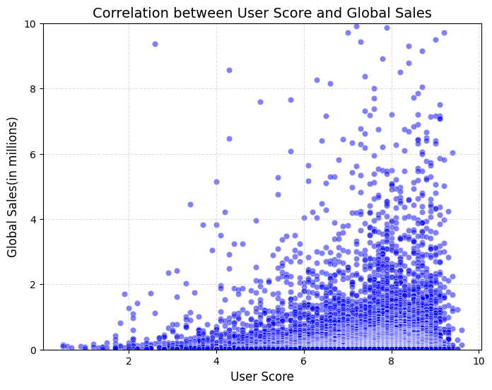

```python
plt.figure(figsize=(8,6))
sns.scatterplot(x='User_Score', y='Global_Sales', data=clean_data, color='blue', alpha=0.5)
plt.title("Correlation between User Score and Global Sales", fontsize=14)
plt.xlabel("User Score", fontsize=12)
plt.ylabel("Global Sales(in millions)", fontsize=12)
plt.grid(True, linestyle='--', alpha=0.4)
plt.ylim(0,10)
plt.show()
```

As you can see the scatterplot above, this shows there is a weak positive trend between the user score and global sales. Most of the points are low on the sales axis,even for the higher user scores. This supports the low correlation value we found, meaning the user score is not a good candidate to predict global sales.

The third test is to use the simple linear regression to **figure out if the critic score can predict the global sales**. The reason to use this test is because this simple regression helps us to quantify the strength and direction of the effect of one variable has on another. It is very useful for predictive analysis, especially in this case using critic scores to predict global sales.

```python
from scipy.stats import linregress
slope, intercept, r_value, p_value, std_err = linregress(clean_data['Critic_Score'], clean_data['Global_Sales'])
print("Slope: ",slope)
print("Intercept: ",intercept)
print("R-squared: ", r_value)
print("P-value: ", p_value)
```

```
Slope:  0.03363194553518352
Intercept:  -1.585797289713225
R-squared:  0.23755572228274263
P-value:  3.5137111423153527e-88
```

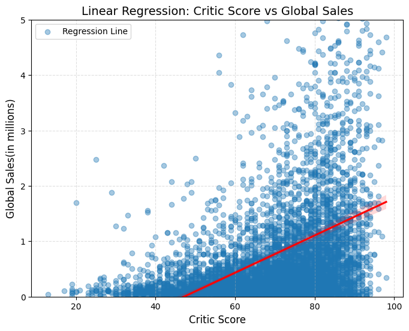

```python
plt.figure(figsize=(8,6))
sns.regplot(x='Critic_Score', y='Global_Sales', data=clean_data, scatter_kws={'alpha':0.4}, line_kws={'color':'red'})
plt.title("Linear Regression: Critic Score vs Global Sales", fontsize=14)
plt.xlabel("Critic Score", fontsize=12)
plt.ylabel("Global Sales(in millions)", fontsize=12)
plt.grid(True, linestyle='--', alpha=0.4)
plt.ylim(0,5)
plt.legend(["Regression Line"], loc="upper left", fontsize=10)
plt.show()
```

Based on the regression plot above, the red regression line shows a clear upward trend--as critic scores increase, the global sales tend to increase as well. However, the actual data points(the blue dots) are little widely scattered around the line, especially at higher scores. This suggests that while critic scores help predict global sales to some extend, there are also many other factors that play a role in increasing a game's sales.

**Primary Analysis**

After conducting the testings in data exploration and statistics summary section, I decided to use ridge regression because not only that I'm dealing with numerical predictions( specifically, how well critic scores can predict global video game sales) for analysis, but also will help to reduce overfitting by removing any large coefficients/numbers from the analysis. This is very useful when there is huge chance that a random fluctuations or noise is present in the large dataset.

**ML Algorithm Design/Development and ML Algorithm Traning and Test Data Analysis**

```python
import numpy as np
from sklearn.linear_model import Ridge
from sklearn.model_selection import train_test_split
from sklearn.metrics import mean_squared_error, r2_score

X = clean_data[['Critic_Score']]
y = clean_data[['Global_Sales']]

X_train, X_test, y_train, y_test = train_test_split(X,y,test_size=0.2, random_state=42)

ridge_model = Ridge(alpha=1.0)
ridge_model.fit(X_train,y_train)

y_pred = ridge_model.predict(X_test)

mse = mean_squared_error(y_test,y_pred)
r2_scores = r2_score(y_test,y_pred)

print("Ridge Regression Coefficient: ", ridge_model.coef_[0])
print("Intercept: ",ridge_model.intercept_)
print("Mean Square Error: ",mse)
print("R_squared on test set: ",r2_scores)
```

```
Ridge Regression Coefficient:  0.032953423610560806
Intercept:  [-1.54798497]
Mean Square Error:  2.458650579451953
R_squared on test set:  0.09530665206056432
```

**Result Analysis**

The Ridge Regression model that I used to create produced a coefficient at around 0.033. This means that for every one point increase in Critic Score, the model can predict a 0.033 million( or 33,000) increase in global sales. The R-squared value on the test was around 0.095. This indicates that the model can only explain about 9.5% of the variance in global sales. For the mean-squared error, it was around 2.46, which indicates that the predictions deviate notably from actual sales.

**Visualization**

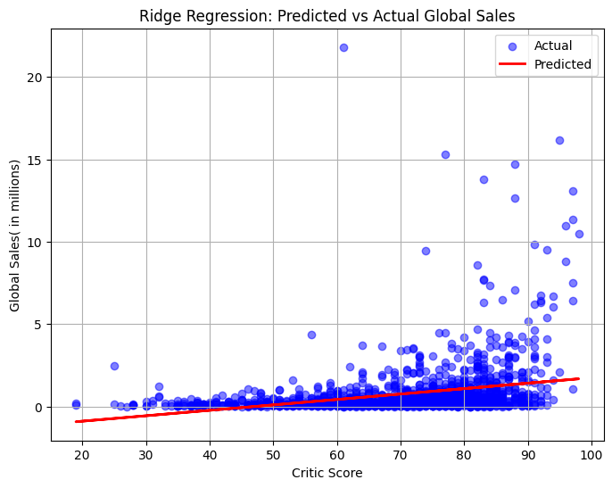

```python
import matplotlib.pyplot as plt
plt.figure(figsize=(8,6))
plt.scatter(X_test,y_test,color='blue',alpha=0.5,label='Actual')
plt.plot(X_test,y_pred,color='red',linewidth=2,label='Predicted')
plt.xlabel("Critic Score")
plt.ylabel("Global Sales( in millions)")
plt.title("Ridge Regression: Predicted vs Actual Global Sales")
plt.legend()
plt.grid(True)
plt.show()
```

**Result Analysis continued**

As you can see the plot above, the red regression line represents the model's predictions. It is shown that it is relatively flat and underestimated the peak in actual global sales. Many actual data points lie far away above the predicted line, specifically for games with higher critic scores. This indicates that the model may struggle to capture the variability in high-selling games.

**Insights and Conclusion**

While we can safely say that there is a statistically siginficant relationship between critic scores and global sales, the critic score alone is not the strong predictor of global sales.The low R-squared value indicates that many other factors may have likely influenced a game's commercial success. For an uninformed reader, this shows that good reviews alone do not guarantee high global sales. For informed audiences, this analysis highlights the importance of having the model include additional features like franchise popularity or marketing budgets, to improve predictive accuracy.